# Model post processing

Author

Fabian Arntz

Published

July 11, 2024

```
false
```

```julia
function row_diff(a)
   b = similar(a)
   b[1,:] .= 0
   for i in 2:size(a,1)
         b[i,:] .= a[i,:] .- a[i-1,:]
   end
   return b
end

function lrt_table(nms,mods,lrt)
   DataFrame(;
      name = nms,
      dof=dof.(mods),
      deviance=deviance.(mods),
      AIC=aic.(mods),
      AIC_dif=row_diff(aic.(mods)),
      AICc=aicc.(mods),
      BIC=bic.(mods),
      BIC_dif=row_diff(bic.(mods)),
      χ²=vcat(:., round.(lrt.tests.deviancediff, digits=3)),
      χ²_dof=vcat(:., round.(lrt.tests.dofdiff, digits=3)),
      pvalue=vcat(:., round.(lrt.tests.pvalues, digits=3)),
      )
end

function mpar_table(nms,mods)
   df = DataFrame(;
      name = nms,
      dof=dof.(mods),
      deviance=deviance.(mods),
      deviance_dif=row_diff(deviance.(mods)),
      AIC=aic.(mods),
      AIC_dif=row_diff(aic.(mods)),
      BIC=bic.(mods),
      BIC_dif=row_diff(bic.(mods)),
      )
end

function fit_loop(models, formulas, data)
   df = DataFrame()
   for i=1:length(models)
   global m = fit(MixedModel, formulas[i], data, contrasts=contr);
   df = append!(df,DataFrame(models = models[i], singular = issingular(m)));
   @eval $(Symbol(models[i])) = deepcopy(m);
   end
   return df
end

function fit_loop_save(models, formulas, data, location)
   df = DataFrame()
   for i=1:length(models)
   global m = fit(MixedModel, formulas[i], data; contrasts=contr);
   saveoptsum(location * models[i] * ".json", m);
   df = append!(df,DataFrame(models = models[i], singular = issingular(m)));
   @eval $(Symbol(models[i])) = deepcopy(m);
   end
   return df
end


function fit_loop_load(models, formulas, data, location)
   df = DataFrame()
   for i=1:length(models)
   global m = LinearMixedModel(formulas[i], data; contrasts=contr);
   restoreoptsum!(m, location * models[i] * ".json");
   df = append!(df,DataFrame(models = models[i], singular = issingular(m)));
   @eval $(Symbol(models[i])) = deepcopy(m);
   end
   return df
end

function glmm_fit_loop(models, formulas, data)
   df = DataFrame()
   for i=1:length(models)
   global m = fit(MixedModel, formulas[i], data, dist; nAGQ, contrasts=contr);
   df = append!(df,DataFrame(models = models[i], singular = issingular(m)));
   @eval $(Symbol(models[i])) = deepcopy(m);
   end
   return df
end

function glmm_fit_loop_save(models, formulas, data, location)
   df = DataFrame()
   for i=1:length(models)
   global m = fit(MixedModel, formulas[i], data, dist; nAGQ, contrasts=contr);
   saveoptsum(location * models[i] * ".json", m);
   df = append!(df,DataFrame(models = models[i], singular = issingular(m)));
   @eval $(Symbol(models[i])) = deepcopy(m);
   end
   return df
end

function glmm_fit_loop_load(models, formulas, data, location)
   df = DataFrame()
   for i=1:length(models)
   global m = GeneralizedLinearMixedModel(formulas[i], data, dist; contrasts=contr);
   restoreoptsum!(m, location * models[i] * ".json");
   df = append!(df,DataFrame(models = models[i], singular = issingular(m)));
   @eval $(Symbol(models[i])) = deepcopy(m);
   end
   return df
end
```

```
glmm_fit_loop_load (generic function with 1 method)
```

# 1 data read

```julia
Data = @chain DataFrame(XLSX.readtable("data/dat_analysis.xlsx", "Sheet1")) # 134,940 (old 133,675 (old 133,403))

dat1 = @chain Data begin
  select(:Subj, :alc_g, :alc_b, :alc_l, :alc_l2, :gender, :a1, :a2, :a3, :wd, :ld, :hd, :d1, :d2, :d3, :jd, :yd_sin, :yearday, :mday);
  @transform(
    :Subj = :Subj,
    :mday = real(:mday),
    :alc_g = real(:alc_g),
    :alc_l = real(:alc_l),
    :alc_l2 = real(:alc_l2),
    :alc_b = real(:alc_b),
    :gender = :gender,
    :a1 = real(:a1),
    :a2 = real(:a2),
    :a3 = real(:a3),
    :wd = :wd,
    :ld = :ld,
    :hd = :hd,
    :d1 = real(:d1),
    :d2 = real(:d2),
    :d3 = real(:d3),
    :jd = :jd,
    :yd_sin = real(:yd_sin),
    :yearday = real(:yearday))
end;


contr = Dict(
  :Subj => Grouping(),
  :gender => EffectsCoding(; levels=["woman", "man"]),
  :ld => EffectsCoding(; levels=["ld0", "ld1"]),
  :hd => EffectsCoding(; levels=["hd0", "hd1"]),
  :wd => EffectsCoding(; levels=["wd0", "wd1"]),
  :jd => HypothesisCoding(
    [
       -1  1  0  # dry january
       -1  0  1  # drinking december
    ];
    levels=["other", "January", "December"],
    labels=["dry_jan", "dri_dec"])
  );
```

# 2 Main model fitting

Model determined through the model selection process

```julia
f_p1 = [@formula alc_l ~ 1 + a1 + gender + a1&gender + wd + hd + ld + yd_sin + jd + d1+d2+d3 + (ld + hd + a1)&wd + jd&(ld + hd) +
                        zerocorr(1 | Subj) + (0 + wd + hd | Subj)  + (0 + yd_sin + jd | Subj);]
m_p1 = ["lmm_mm"]

fit_loop_save(m_p1, f_p1, dat1, "./save/")
#fit_loop_load(m_p1, f_p1, dat1, "./save/")
```

1×2 DataFrame

| Row | models String | singular Bool |
| --- | --- | --- |
| 1 | lmm_mm | false |

```julia
VarCorr(lmm_mm)
```

|  | Column | Variance | Std.Dev | Corr. |  |  |  |  |
| --- | --- | --- | --- | --- | --- | --- | --- | --- |
| Subj | (Intercept) | 0.826884 | 0.909332 |  |  |  |  |  |
|  | wd: wd1 | 0.066146 | 0.257189 | . |  |  |  |  |
|  | hd: hd1 | 0.036146 | 0.190120 | . | +0.59 |  |  |  |
|  | yd_sin | 0.143593 | 0.378937 | . | . | . |  |  |
|  | jd: dry_jan | 0.519164 | 0.720530 | . | . | . | +0.30 |  |
|  | jd: dri_dec | 0.231567 | 0.481214 | . | . | . | +0.51 | +0.11 |
| Residual |  | 2.632097 | 1.622374 |  |  |  |  |  |

```julia
lmm_mm
```

|  | Est. | SE | z | p | σ_Subj |
| --- | --- | --- | --- | --- | --- |
| (Intercept) | 2.5281 | 0.0450 | 56.14 | <1e-99 | 0.9093 |
| a1 | 0.0267 | 0.0030 | 8.95 | <1e-18 |  |
| gender: man | 0.1773 | 0.0384 | 4.62 | <1e-05 |  |
| wd: wd1 | 0.2694 | 0.0196 | 13.74 | <1e-42 | 0.2572 |
| hd: hd1 | 0.2089 | 0.0216 | 9.65 | <1e-21 | 0.1901 |
| ld: ld1 | 0.0225 | 0.0169 | 1.33 | 0.1826 |  |
| yd_sin | 0.1814 | 0.0184 | 9.87 | <1e-22 | 0.3789 |
| jd: dry_jan | -0.3246 | 0.0659 | -4.93 | <1e-06 | 0.7205 |
| jd: dri_dec | 0.7713 | 0.0433 | 17.81 | <1e-70 | 0.4812 |
| d1 | -0.0275 | 0.0107 | -2.56 | 0.0104 |  |
| d2 | 0.0659 | 0.0071 | 9.24 | <1e-19 |  |
| d3 | -0.0338 | 0.0045 | -7.45 | <1e-13 |  |
| a1 & gender: man | 0.0007 | 0.0029 | 0.23 | 0.8172 |  |
| ld: ld1 & wd: wd1 | -0.0312 | 0.0106 | -2.93 | 0.0034 |  |
| hd: hd1 & wd: wd1 | -0.1194 | 0.0136 | -8.80 | <1e-17 |  |
| a1 & wd: wd1 | -0.0084 | 0.0009 | -9.36 | <1e-20 |  |
| jd: dry_jan & ld: ld1 | 0.0178 | 0.0376 | 0.47 | 0.6352 |  |
| jd: dri_dec & ld: ld1 | 0.1672 | 0.0300 | 5.58 | <1e-07 |  |
| jd: dry_jan & hd: hd1 | -0.1734 | 0.0539 | -3.22 | 0.0013 |  |
| jd: dri_dec & hd: hd1 | 0.3212 | 0.0316 | 10.16 | <1e-23 |  |
| Residual | 1.6224 |  |  |  |  |

```julia
ranef_Subj_mm = DataFrame(raneftables(lmm_mm).Subj);
rename!(ranef_Subj_mm,[:Subj, :GrandMean, :weekday, :holiday, :annual, :dryJan, :drinkDec])

XLSX.writetable("data/ranef_mm.xlsx",
   transform(ranef_Subj_mm,
      :Subj => Array => :Subj); overwrite = true)
```

## 2.1 model performance

### 2.1.1 R2

```julia
MixedModelsExtras.r2(lmm_mm)
```

```
0.09082828708466634
```

### 2.1.2 ICC

```julia
MixedModelsExtras.icc(lmm_mm)
```

```
0.40926063026161547
```

### 2.1.3 QQplot

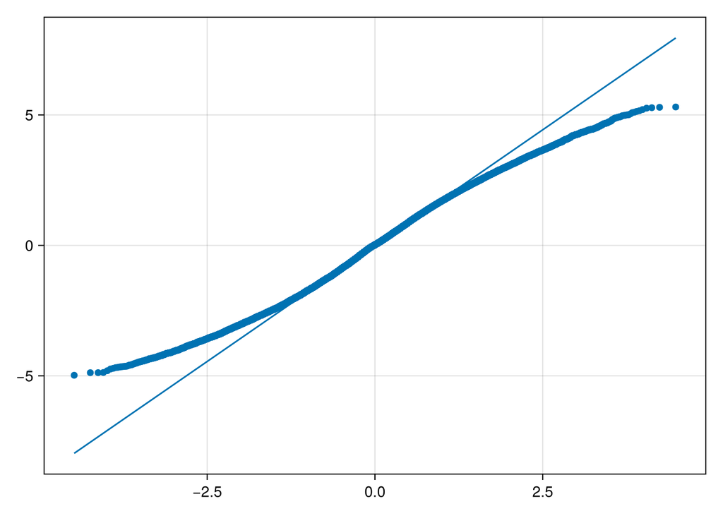

```julia
qqnorm(lmm_mm)
```

### 2.1.4 QQcaterpillar

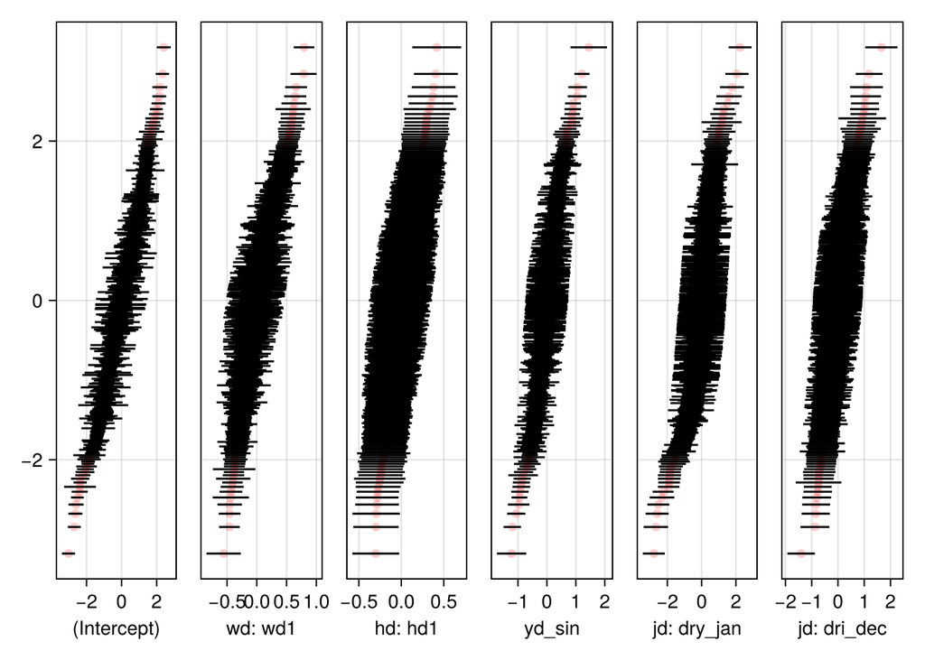

```julia
qqcaterpillar(lmm_mm)
```

### 2.1.5 Srinkage plot

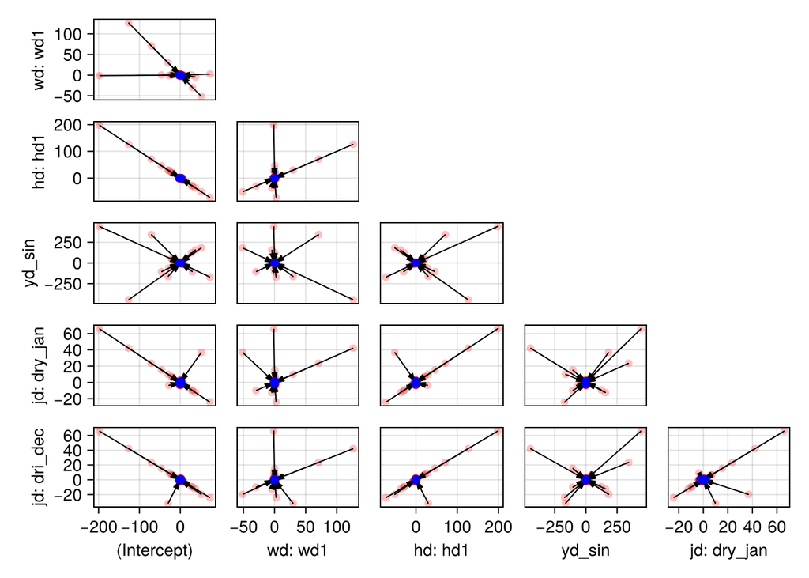

```julia
shrinkageplot(lmm_mm)
```

# 3 drinkday frequency

glmm approach using the main model formular focusing the distribution of drinkdays versus non-drink days to assess drink days frequency (i.e. how often do people drink).

Sinus centering was determined aswell and yielded centering at day 248 (identical to the main model) [see 05_sinusloop.html].

```julia
nAGQ = 1
dist = Bernoulli()
f_p2 = [@formula alc_b ~ 1 + a1 + gender + a1&gender + wd + hd + ld + yd_sin + d1+d2+d3 + jd + (ld + hd + a1)&wd + jd&(ld + hd) +
                        zerocorr(1 | Subj) + (0 + wd + hd | Subj)  + (0 + yd_sin + jd | Subj);]
m_p2 = ["glmm_df"]
#glmm_fit_loop_save(m_p2, f_p2, dat1, "./save/")
glmm_fit_loop_load(m_p2, f_p2, dat1, "./save/")
```

1×2 DataFrame

| Row | models String | singular Bool |
| --- | --- | --- |
| 1 | glmm_df | false |

```julia
VarCorr(glmm_df)
```

|  | Column | Variance | Std.Dev | Corr. |  |  |  |  |
| --- | --- | --- | --- | --- | --- | --- | --- | --- |
| Subj | (Intercept) | 2.331361 | 1.526879 |  |  |  |  |  |
|  | wd: wd1 | 0.079553 | 0.282052 | . |  |  |  |  |
|  | hd: hd1 | 0.057099 | 0.238955 | . | +0.64 |  |  |  |
|  | yd_sin | 0.346821 | 0.588915 | . | . | . |  |  |
|  | jd: dry_jan | 1.215163 | 1.102344 | . | . | . | +0.32 |  |
|  | jd: dri_dec | 0.480184 | 0.692953 | . | . | . | +0.51 | +0.10 |

```julia
glmm_df
```

|  | Est. | SE | z | p | σ_Subj |
| --- | --- | --- | --- | --- | --- |
| (Intercept) | 0.9626 | 0.0754 | 12.77 | <1e-36 | 1.5269 |
| a1 | 0.0522 | 0.0050 | 10.44 | <1e-24 |  |
| gender: man | 0.1361 | 0.0643 | 2.12 | 0.0342 |  |
| wd: wd1 | 0.3536 | 0.0297 | 11.91 | <1e-32 | 0.2821 |
| hd: hd1 | 0.3152 | 0.0349 | 9.04 | <1e-18 | 0.2390 |
| ld: ld1 | 0.0696 | 0.0272 | 2.56 | 0.0105 |  |
| yd_sin | 0.2511 | 0.0291 | 8.63 | <1e-17 | 0.5889 |
| d1 | -0.0482 | 0.0158 | -3.04 | 0.0023 |  |
| d2 | 0.0975 | 0.0107 | 9.07 | <1e-18 |  |
| d3 | -0.0468 | 0.0066 | -7.05 | <1e-11 |  |
| jd: dry_jan | -0.3994 | 0.1037 | -3.85 | 0.0001 | 1.1023 |
| jd: dri_dec | 1.1708 | 0.0759 | 15.43 | <1e-53 | 0.6930 |
| a1 & gender: man | 0.0022 | 0.0049 | 0.44 | 0.6584 |  |
| ld: ld1 & wd: wd1 | -0.0140 | 0.0170 | -0.82 | 0.4108 |  |
| hd: hd1 & wd: wd1 | -0.1347 | 0.0220 | -6.13 | <1e-09 |  |
| a1 & wd: wd1 | -0.0063 | 0.0012 | -5.33 | <1e-07 |  |
| jd: dry_jan & ld: ld1 | 0.0519 | 0.0593 | 0.88 | 0.3815 |  |
| jd: dri_dec & ld: ld1 | 0.2785 | 0.0488 | 5.71 | <1e-07 |  |
| jd: dry_jan & hd: hd1 | -0.1487 | 0.0846 | -1.76 | 0.0788 |  |
| jd: dri_dec & hd: hd1 | 0.5170 | 0.0584 | 8.85 | <1e-18 |  |

## 3.1 model performance

### 3.1.1 QQplot

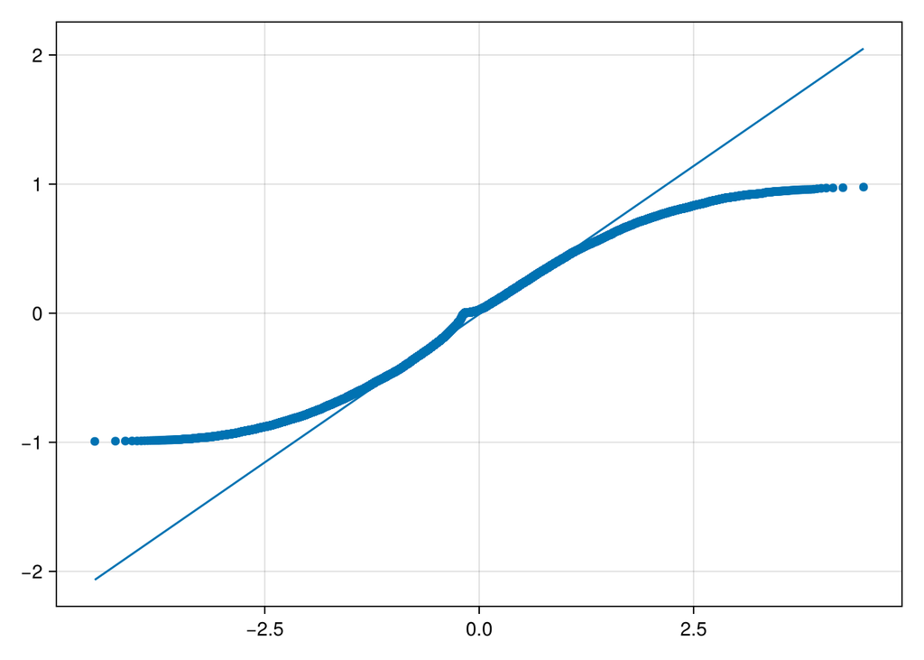

```julia
qqnorm(glmm_df)
```

### 3.1.2 QQcaterpillar

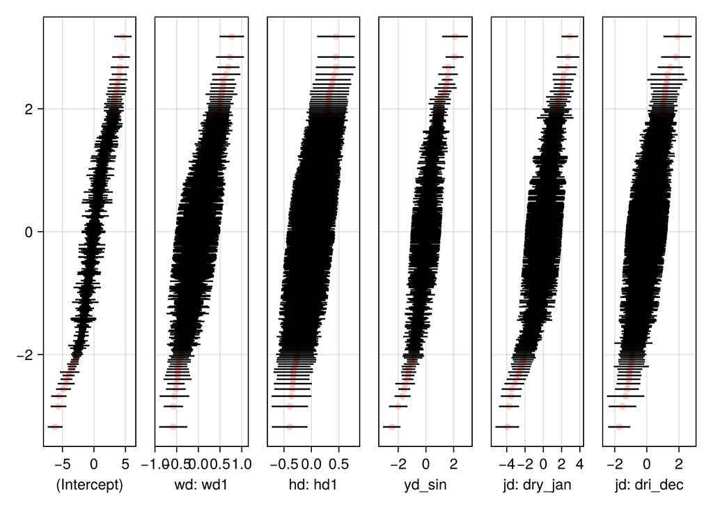

```julia
qqcaterpillar(glmm_df)
```

### 3.1.3 Srinkage plot

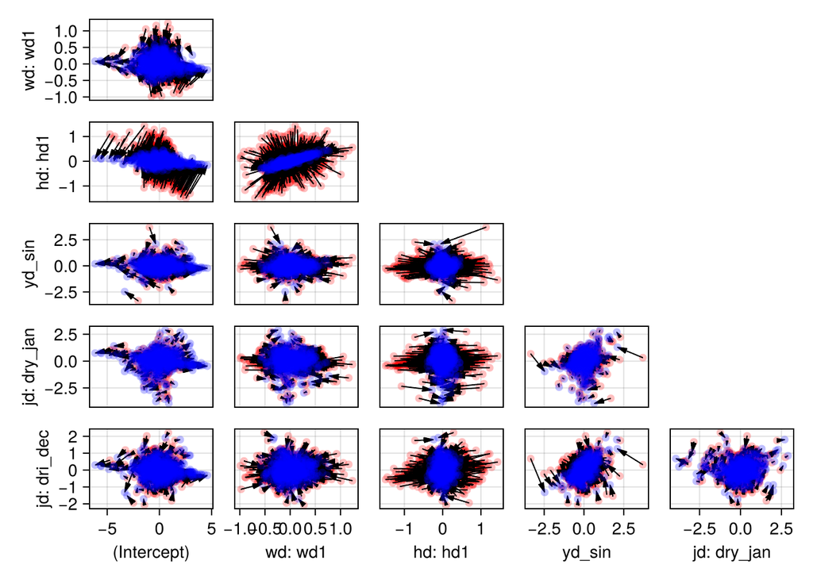

```julia
shrinkageplot(glmm_df)
```

```julia
ranef_Subj_df = DataFrame(raneftables(glmm_df).Subj);
rename!(ranef_Subj_df,[:Subj, :GrandMean, :weekday, :holiday, :annual, :dryJan, :drinkDec])

XLSX.writetable("data/ranef_df.xlsx",
   transform(ranef_Subj_df,
      :Subj => Array => :Subj); overwrite = true)
```

# 4 lmm - drinkamount

Sinus centering was determined aswell and yielded centering at day 250 (two days later than the main model) [see 05_sinusloop.html].

```julia
dat2 = filter(:alc_b => x -> x == 1, dat1);

f_p3 = [@formula alc_l2 ~ 1 + a1 + gender + a1&gender + wd + hd + ld + yd_sin + jd + d1+d2+d3 + (ld + hd + a1)&wd + jd&(ld + hd) +
                        zerocorr(1 | Subj) + (0 + wd + hd | Subj)  + (0 + yd_sin + jd | Subj);]
m_p3 = ["lmm_da"]

#fit_loop_save(m_p3, f_p3, dat2, "./save/")
fit_loop_load(m_p3, f_p3, dat2, "./save/")
```

1×2 DataFrame

| Row | models String | singular Bool |
| --- | --- | --- |
| 1 | lmm_da | false |

```julia
VarCorr(lmm_da)
```

|  | Column | Variance | Std.Dev | Corr. |  |  |  |  |
| --- | --- | --- | --- | --- | --- | --- | --- | --- |
| Subj | (Intercept) | 0.1673644 | 0.4091020 |  |  |  |  |  |
|  | wd: wd1 | 0.0077917 | 0.0882707 | . |  |  |  |  |
|  | hd: hd1 | 0.0066086 | 0.0812935 | . | +0.61 |  |  |  |
|  | yd_sin | 0.0181150 | 0.1345919 | . | . | . |  |  |
|  | jd: dry_jan | 0.0188967 | 0.1374651 | . | . | . | +0.31 |  |
|  | jd: dri_dec | 0.0246896 | 0.1571293 | . | . | . | +0.41 | +0.31 |
| Residual |  | 0.3848359 | 0.6203514 |  |  |  |  |  |

```julia
lmm_da
```

|  | Est. | SE | z | p | σ_Subj |
| --- | --- | --- | --- | --- | --- |
| (Intercept) | 3.8739 | 0.0211 | 183.70 | <1e-99 | 0.4091 |
| a1 | -0.0008 | 0.0014 | -0.57 | 0.5686 |  |
| gender: man | 0.1827 | 0.0174 | 10.51 | <1e-25 |  |
| wd: wd1 | 0.0759 | 0.0085 | 8.96 | <1e-18 | 0.0883 |
| hd: hd1 | 0.0573 | 0.0110 | 5.21 | <1e-06 | 0.0813 |
| ld: ld1 | -0.0056 | 0.0070 | -0.80 | 0.4265 |  |
| yd_sin | 0.0350 | 0.0075 | 4.66 | <1e-05 | 0.1346 |
| jd: dry_jan | -0.1355 | 0.0309 | -4.38 | <1e-04 | 0.1375 |
| jd: dri_dec | 0.2058 | 0.0183 | 11.25 | <1e-28 | 0.1571 |
| d1 | 0.0011 | 0.0055 | 0.19 | 0.8464 |  |
| d2 | 0.0056 | 0.0034 | 1.61 | 0.1067 |  |
| d3 | -0.0047 | 0.0024 | -1.98 | 0.0477 |  |
| a1 & gender: man | 0.0008 | 0.0013 | 0.58 | 0.5622 |  |
| ld: ld1 & wd: wd1 | -0.0212 | 0.0050 | -4.23 | <1e-04 |  |
| hd: hd1 & wd: wd1 | -0.0527 | 0.0062 | -8.46 | <1e-16 |  |
| a1 & wd: wd1 | -0.0035 | 0.0004 | -10.06 | <1e-23 |  |
| jd: dry_jan & ld: ld1 | -0.0209 | 0.0134 | -1.55 | 0.1205 |  |
| jd: dri_dec & ld: ld1 | 0.0165 | 0.0136 | 1.21 | 0.2262 |  |
| jd: dry_jan & hd: hd1 | -0.1256 | 0.0291 | -4.32 | <1e-04 |  |
| jd: dri_dec & hd: hd1 | 0.1051 | 0.0139 | 7.59 | <1e-13 |  |
| Residual | 0.6204 |  |  |  |  |

## 4.1 model performance

### 4.1.1 R2

```julia
MixedModelsExtras.r2(lmm_da)
```

```
0.07993223304286769
```

### 4.1.2 ICC

```julia
MixedModelsExtras.icc(lmm_da)
```

```
0.38749846424720197
```

### 4.1.3 QQplot

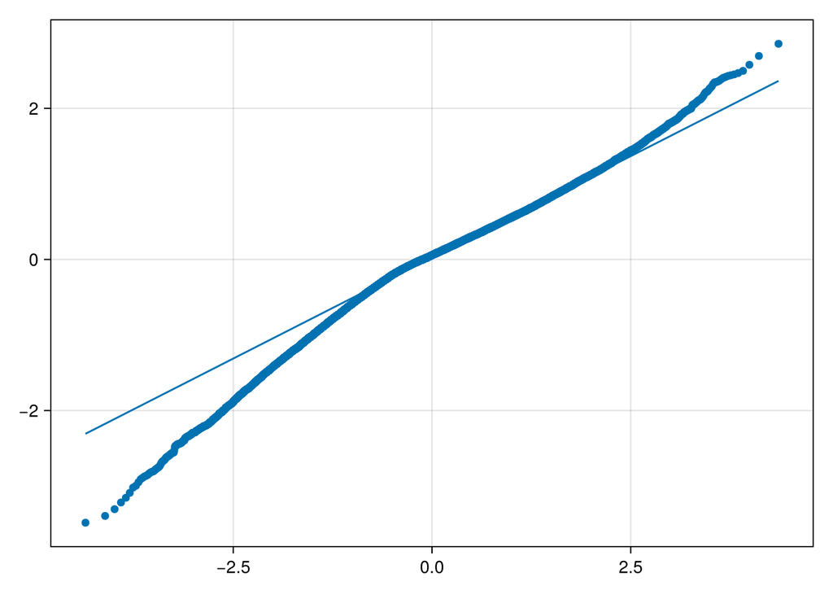

```julia
qqnorm(lmm_da)
```

### 4.1.4 QQcaterpillar

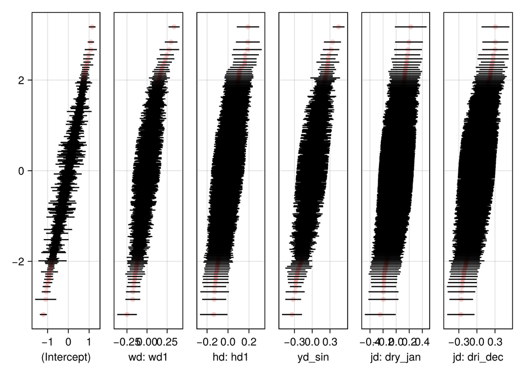

```julia
qqcaterpillar(lmm_da)
```

### 4.1.5 Srinkage plot

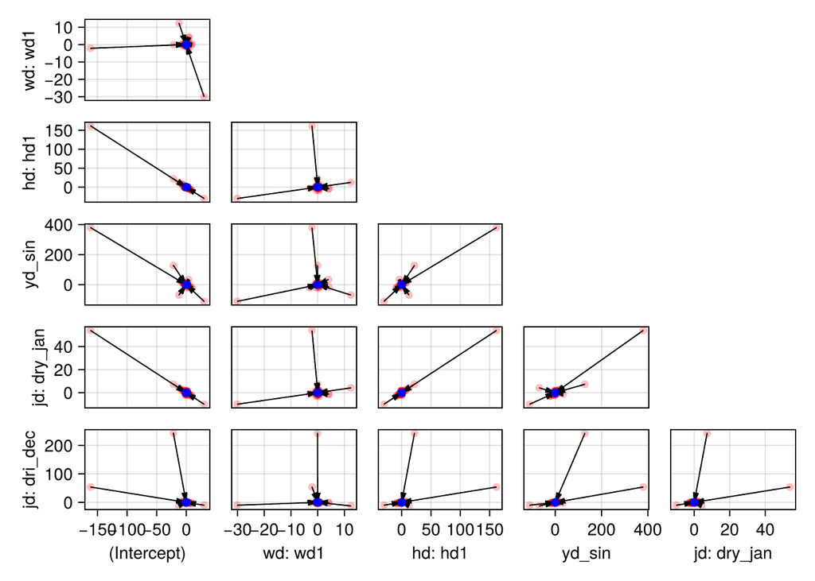

```julia
shrinkageplot(lmm_da)
```

```julia
ranef_Subj_da = DataFrame(raneftables(lmm_da).Subj);
rename!(ranef_Subj_da,[:Subj, :GrandMean, :weekday, :holiday, :annual, :dryJan, :drinkDec])

XLSX.writetable("data/ranef_da.xlsx",
   transform(ranef_Subj_da,
      :Subj => Array => :Subj); overwrite = true)
```

# 5 Tables

z statistics of all three models

```julia
ct_mm = coeftable(lmm_mm)
ct_df = coeftable(glmm_df)
ct_da = coeftable(lmm_da)
DataFrame(var = ct_mm.rownms,
          mm = ct_mm.cols[3],
          df = ct_df.cols[3],
          da = ct_da.cols[3])
```

20×4 DataFrame

| Row | var String | mm Float64 | df Float64 | da Float64 |
| --- | --- | --- | --- | --- |
| 1 | (Intercept) | 56.1395 | 12.7652 | 183.705 |
| 2 | a1 | 8.95195 | 10.4356 | -0.570159 |
| 3 | gender: man | 4.62389 | 2.11742 | 10.5098 |
| 4 | wd: wd1 | 13.7421 | 11.9141 | 8.9615 |
| 5 | hd: hd1 | 9.65407 | 9.04124 | 5.20927 |
| 6 | ld: ld1 | 1.33271 | 2.55749 | -0.795149 |
| 7 | yd_sin | 9.8725 | 8.62928 | 4.65843 |
| 8 | jd: dry_jan | -4.92789 | -3.04456 | -4.38449 |
| 9 | jd: dri_dec | 17.8133 | 9.07319 | 11.2538 |
| 10 | d1 | -2.56199 | -7.05017 | 0.193721 |
| 11 | d2 | 9.23658 | -3.85038 | 1.61306 |
| 12 | d3 | -7.44963 | 15.4342 | -1.98016 |
| 13 | a1 & gender: man | 0.231182 | 0.442058 | 0.57963 |
| 14 | ld: ld1 & wd: wd1 | -2.93267 | -0.822564 | -4.22739 |
| 15 | hd: hd1 & wd: wd1 | -8.79746 | -6.12628 | -8.46447 |
| 16 | a1 & wd: wd1 | -9.3585 | -5.33003 | -10.0585 |
| 17 | jd: dry_jan & ld: ld1 | 0.474477 | 0.875197 | -1.55264 |
| 18 | jd: dri_dec & ld: ld1 | 5.57631 | 5.70811 | 1.21033 |
| 19 | jd: dry_jan & hd: hd1 | -3.21757 | -1.75758 | -4.32209 |
| 20 | jd: dri_dec & hd: hd1 | 10.1623 | 8.85052 | 7.58755 |

# 6 90 day dropouts removed

Additional models rendered for drinking frequency and drinking amounts excluding dropouts within the first 90 days

## 6.1 df

```julia
dat3 = filter(:mday => x -> x > 90, dat1)

m_p4 = ["glmm_df90"]

#glmm_fit_loop_save(m_p4, f_p2, dat3, "./save/")
glmm_fit_loop_load(m_p4, f_p2, dat3, "./save/")
```

1×2 DataFrame

| Row | models String | singular Bool |
| --- | --- | --- |
| 1 | glmm_df90 | false |

```julia
VarCorr(glmm_df90)
```

|  | Column | Variance | Std.Dev | Corr. |  |  |  |  |
| --- | --- | --- | --- | --- | --- | --- | --- | --- |
| Subj | (Intercept) | 1.248747 | 1.117474 |  |  |  |  |  |
|  | wd: wd1 | 0.546804 | 0.739462 | . |  |  |  |  |
|  | hd: hd1 | 0.720159 | 0.848622 | . | +0.04 |  |  |  |
|  | yd_sin | 0.844137 | 0.918769 | . | . | . |  |  |
|  | jd: dry_jan | 1.132360 | 1.064124 | . | . | . | +0.09 |  |
|  | jd: dri_dec | 0.677189 | 0.822915 | . | . | . | +0.15 | +0.03 |

```julia
glmm_df90
```

|  | Est. | SE | z | p | σ_Subj |
| --- | --- | --- | --- | --- | --- |
| (Intercept) | 0.8773 | 0.0656 | 13.37 | <1e-40 | 1.1175 |
| a1 | 0.0495 | 0.0042 | 11.73 | <1e-31 |  |
| gender: man | 0.1196 | 0.0536 | 2.23 | 0.0257 |  |
| wd: wd1 | 0.3345 | 0.0421 | 7.95 | <1e-14 | 0.7395 |
| hd: hd1 | 0.2106 | 0.0506 | 4.16 | <1e-04 | 0.8486 |
| ld: ld1 | 0.1185 | 0.0285 | 4.16 | <1e-04 |  |
| yd_sin | 0.2442 | 0.0420 | 5.81 | <1e-08 | 0.9188 |
| d1 | -0.0442 | 0.0165 | -2.69 | 0.0072 |  |
| d2 | 0.1109 | 0.0114 | 9.70 | <1e-21 |  |
| d3 | -0.0509 | 0.0069 | -7.43 | <1e-12 |  |
| jd: dry_jan | -0.3775 | 0.1078 | -3.50 | 0.0005 | 1.0641 |
| jd: dri_dec | 0.9550 | 0.0779 | 12.26 | <1e-33 | 0.8229 |
| a1 & gender: man | 0.0032 | 0.0042 | 0.77 | 0.4392 |  |
| ld: ld1 & wd: wd1 | -0.0061 | 0.0179 | -0.34 | 0.7340 |  |
| hd: hd1 & wd: wd1 | -0.1464 | 0.0225 | -6.49 | <1e-10 |  |
| a1 & wd: wd1 | -0.0078 | 0.0026 | -3.00 | 0.0027 |  |
| jd: dry_jan & ld: ld1 | 0.1846 | 0.0598 | 3.09 | 0.0020 |  |
| jd: dri_dec & ld: ld1 | 0.2837 | 0.0500 | 5.67 | <1e-07 |  |
| jd: dry_jan & hd: hd1 | -0.1386 | 0.0904 | -1.53 | 0.1253 |  |
| jd: dri_dec & hd: hd1 | 0.3950 | 0.0573 | 6.90 | <1e-11 |  |

## 6.2 da

```julia
dat4 = filter(:mday => x -> x > 90, dat2)

m_p5 = ["lmm_da90"]

#fit_loop_save(m_p5, f_p3, dat4, "./save/")
fit_loop_load(m_p5, f_p3, dat4, "./save/")
```

1×2 DataFrame

| Row | models String | singular Bool |
| --- | --- | --- |
| 1 | lmm_da90 | false |

```julia
VarCorr(lmm_da90)
```

|  | Column | Variance | Std.Dev | Corr. |  |  |  |  |
| --- | --- | --- | --- | --- | --- | --- | --- | --- |
| Subj | (Intercept) | 0.1621232 | 0.4026453 |  |  |  |  |  |
|  | wd: wd1 | 0.0076327 | 0.0873652 | . |  |  |  |  |
|  | hd: hd1 | 0.0064223 | 0.0801391 | . | +0.60 |  |  |  |
|  | yd_sin | 0.0177919 | 0.1333863 | . | . | . |  |  |
|  | jd: dry_jan | 0.0189875 | 0.1377952 | . | . | . | +0.31 |  |
|  | jd: dri_dec | 0.0248444 | 0.1576210 | . | . | . | +0.41 | +0.31 |
| Residual |  | 0.3854318 | 0.6208315 |  |  |  |  |  |

```julia
lmm_da90
```

|  | Est. | SE | z | p | σ_Subj |
| --- | --- | --- | --- | --- | --- |
| (Intercept) | 3.8723 | 0.0214 | 180.61 | <1e-99 | 0.4026 |
| a1 | -0.0001 | 0.0014 | -0.07 | 0.9413 |  |
| gender: man | 0.1853 | 0.0179 | 10.35 | <1e-24 |  |
| wd: wd1 | 0.0754 | 0.0085 | 8.82 | <1e-17 | 0.0874 |
| hd: hd1 | 0.0576 | 0.0110 | 5.23 | <1e-06 | 0.0801 |
| ld: ld1 | -0.0056 | 0.0071 | -0.79 | 0.4300 |  |
| yd_sin | 0.0356 | 0.0075 | 4.73 | <1e-05 | 0.1334 |
| jd: dry_jan | -0.1356 | 0.0310 | -4.38 | <1e-04 | 0.1378 |
| jd: dri_dec | 0.2076 | 0.0184 | 11.28 | <1e-28 | 0.1576 |
| d1 | 0.0009 | 0.0055 | 0.17 | 0.8687 |  |
| d2 | 0.0055 | 0.0035 | 1.58 | 0.1145 |  |
| d3 | -0.0047 | 0.0024 | -1.96 | 0.0498 |  |
| a1 & gender: man | 0.0006 | 0.0014 | 0.44 | 0.6575 |  |
| ld: ld1 & wd: wd1 | -0.0217 | 0.0050 | -4.30 | <1e-04 |  |
| hd: hd1 & wd: wd1 | -0.0525 | 0.0063 | -8.35 | <1e-16 |  |
| a1 & wd: wd1 | -0.0035 | 0.0004 | -9.97 | <1e-22 |  |
| jd: dry_jan & ld: ld1 | -0.0211 | 0.0135 | -1.56 | 0.1184 |  |
| jd: dri_dec & ld: ld1 | 0.0165 | 0.0137 | 1.20 | 0.2284 |  |
| jd: dry_jan & hd: hd1 | -0.1256 | 0.0291 | -4.31 | <1e-04 |  |
| jd: dri_dec & hd: hd1 | 0.1063 | 0.0139 | 7.63 | <1e-13 |  |
| Residual | 0.6208 |  |  |  |  |

# 7 180 day dropouts removed

Additional models rendered for drinking frequency and drinking amounts excluding dropouts within the first 180 days

## 7.1 df

```julia
dat5 = filter(:mday => x -> x > 180, dat1)

m_p6 = ["glmm_df180"]

#glmm_fit_loop_save(m_p6, f_p2, dat5, "./save/")
glmm_fit_loop_load(m_p6, f_p2, dat5, "./save/")
```

1×2 DataFrame

| Row | models String | singular Bool |
| --- | --- | --- |
| 1 | glmm_df180 | false |

```julia
VarCorr(glmm_df180)
```

|  | Column | Variance | Std.Dev | Corr. |  |  |  |  |
| --- | --- | --- | --- | --- | --- | --- | --- | --- |
| Subj | (Intercept) | 2.417788 | 1.554924 |  |  |  |  |  |
|  | wd: wd1 | 0.079825 | 0.282533 | . |  |  |  |  |
|  | hd: hd1 | 0.049551 | 0.222600 | . | +0.69 |  |  |  |
|  | yd_sin | 0.318134 | 0.564033 | . | . | . |  |  |
|  | jd: dry_jan | 1.185864 | 1.088974 | . | . | . | +0.31 |  |
|  | jd: dri_dec | 0.471734 | 0.686829 | . | . | . | +0.48 | +0.07 |

```julia
glmm_df180
```

|  | Est. | SE | z | p | σ_Subj |
| --- | --- | --- | --- | --- | --- |
| (Intercept) | 1.0090 | 0.0820 | 12.30 | <1e-34 | 1.5549 |
| a1 | 0.0519 | 0.0056 | 9.21 | <1e-19 |  |
| gender: man | 0.1574 | 0.0718 | 2.19 | 0.0283 |  |
| wd: wd1 | 0.3575 | 0.0306 | 11.67 | <1e-30 | 0.2825 |
| hd: hd1 | 0.3364 | 0.0357 | 9.42 | <1e-20 | 0.2226 |
| ld: ld1 | 0.0712 | 0.0279 | 2.55 | 0.0109 |  |
| yd_sin | 0.2496 | 0.0291 | 8.59 | <1e-17 | 0.5640 |
| d1 | -0.0461 | 0.0159 | -2.90 | 0.0037 |  |
| d2 | 0.0994 | 0.0111 | 8.97 | <1e-18 |  |
| d3 | -0.0480 | 0.0067 | -7.12 | <1e-11 |  |
| jd: dry_jan | -0.3286 | 0.1072 | -3.06 | 0.0022 | 1.0890 |
| jd: dri_dec | 1.1815 | 0.0776 | 15.22 | <1e-51 | 0.6868 |
| a1 & gender: man | 0.0077 | 0.0055 | 1.39 | 0.1653 |  |
| ld: ld1 & wd: wd1 | -0.0153 | 0.0175 | -0.87 | 0.3838 |  |
| hd: hd1 & wd: wd1 | -0.1326 | 0.0225 | -5.90 | <1e-08 |  |
| a1 & wd: wd1 | -0.0063 | 0.0012 | -5.06 | <1e-06 |  |
| jd: dry_jan & ld: ld1 | 0.0664 | 0.0610 | 1.09 | 0.2766 |  |
| jd: dri_dec & ld: ld1 | 0.2840 | 0.0502 | 5.66 | <1e-07 |  |
| jd: dry_jan & hd: hd1 | -0.1031 | 0.0874 | -1.18 | 0.2382 |  |
| jd: dri_dec & hd: hd1 | 0.5280 | 0.0596 | 8.86 | <1e-18 |  |

## 7.2 da

```julia
dat6 = filter(:mday => x -> x > 180, dat2)

m_p7 = ["lmm_da180"]

#fit_loop_save(m_p7, f_p3, dat6, "./save/")
fit_loop_load(m_p7, f_p3, dat6, "./save/")
```

1×2 DataFrame

| Row | models String | singular Bool |
| --- | --- | --- |
| 1 | lmm_da180 | false |

```julia
VarCorr(lmm_da180)
```

|  | Column | Variance | Std.Dev | Corr. |  |  |  |  |
| --- | --- | --- | --- | --- | --- | --- | --- | --- |
| Subj | (Intercept) | 0.1610558 | 0.4013176 |  |  |  |  |  |
|  | wd: wd1 | 0.0075555 | 0.0869225 | . |  |  |  |  |
|  | hd: hd1 | 0.0061914 | 0.0786856 | . | +0.58 |  |  |  |
|  | yd_sin | 0.0171269 | 0.1308698 | . | . | . |  |  |
|  | jd: dry_jan | 0.0193394 | 0.1390660 | . | . | . | +0.29 |  |
|  | jd: dri_dec | 0.0258655 | 0.1608276 | . | . | . | +0.40 | +0.32 |
| Residual |  | 0.3834005 | 0.6191934 |  |  |  |  |  |

```julia
lmm_da180
```

|  | Est. | SE | z | p | σ_Subj |
| --- | --- | --- | --- | --- | --- |
| (Intercept) | 3.8663 | 0.0222 | 174.31 | <1e-99 | 0.4013 |
| a1 | 0.0005 | 0.0015 | 0.33 | 0.7448 |  |
| gender: man | 0.1894 | 0.0187 | 10.14 | <1e-23 |  |
| wd: wd1 | 0.0759 | 0.0087 | 8.73 | <1e-17 | 0.0869 |
| hd: hd1 | 0.0569 | 0.0112 | 5.06 | <1e-06 | 0.0787 |
| ld: ld1 | -0.0044 | 0.0072 | -0.62 | 0.5375 |  |
| yd_sin | 0.0355 | 0.0075 | 4.71 | <1e-05 | 0.1309 |
| jd: dry_jan | -0.1220 | 0.0317 | -3.85 | 0.0001 | 0.1391 |
| jd: dri_dec | 0.2097 | 0.0188 | 11.17 | <1e-28 | 0.1608 |
| d1 | 0.0008 | 0.0055 | 0.14 | 0.8888 |  |
| d2 | 0.0043 | 0.0035 | 1.21 | 0.2253 |  |
| d3 | -0.0043 | 0.0024 | -1.77 | 0.0759 |  |
| a1 & gender: man | 0.0000 | 0.0014 | 0.00 | 0.9966 |  |
| ld: ld1 & wd: wd1 | -0.0216 | 0.0051 | -4.22 | <1e-04 |  |
| hd: hd1 & wd: wd1 | -0.0514 | 0.0064 | -8.09 | <1e-15 |  |
| a1 & wd: wd1 | -0.0034 | 0.0004 | -9.33 | <1e-19 |  |
| jd: dry_jan & ld: ld1 | -0.0162 | 0.0138 | -1.18 | 0.2393 |  |
| jd: dri_dec & ld: ld1 | 0.0182 | 0.0140 | 1.30 | 0.1941 |  |
| jd: dry_jan & hd: hd1 | -0.1155 | 0.0297 | -3.89 | 0.0001 |  |
| jd: dri_dec & hd: hd1 | 0.1038 | 0.0141 | 7.36 | <1e-12 |  |
| Residual | 0.6192 |  |  |  |  |

# 8 dropout model overview

## 8.1 drinking frequency

```julia
ct_df90 = coeftable(glmm_df90)
ct_df180 = coeftable(glmm_df180)
DataFrame(var = ct_df.rownms,
          df = ct_df.cols[3],
          df90 = ct_df90.cols[3],
          df180 = ct_df180.cols[3])
```

20×4 DataFrame

| Row | var String | df Float64 | df90 Float64 | df180 Float64 |
| --- | --- | --- | --- | --- |
| 1 | (Intercept) | 12.7652 | 13.3715 | 12.2985 |
| 2 | a1 | 10.4356 | 11.7255 | 9.21012 |
| 3 | gender: man | 2.11742 | 2.23072 | 2.19352 |
| 4 | wd: wd1 | 11.9141 | 7.95412 | 11.6734 |
| 5 | hd: hd1 | 9.04124 | 4.16014 | 9.41502 |
| 6 | ld: ld1 | 2.55749 | 4.16092 | 2.54703 |
| 7 | yd_sin | 8.62928 | 5.81366 | 8.58708 |
| 8 | d1 | -3.04456 | -2.68575 | -2.89873 |
| 9 | d2 | 9.07319 | 9.70106 | 8.97101 |
| 10 | d3 | -7.05017 | -7.42935 | -7.11618 |
| 11 | jd: dry_jan | -3.85038 | -3.50383 | -3.06457 |
| 12 | jd: dri_dec | 15.4342 | 12.2568 | 15.2229 |
| 13 | a1 & gender: man | 0.442058 | 0.773624 | 1.38739 |
| 14 | ld: ld1 & wd: wd1 | -0.822564 | -0.339872 | -0.870956 |
| 15 | hd: hd1 & wd: wd1 | -6.12628 | -6.49176 | -5.89915 |
| 16 | a1 & wd: wd1 | -5.33003 | -3.00193 | -5.06382 |
| 17 | jd: dry_jan & ld: ld1 | 0.875197 | 3.08505 | 1.08794 |
| 18 | jd: dri_dec & ld: ld1 | 5.70811 | 5.67017 | 5.65962 |
| 19 | jd: dry_jan & hd: hd1 | -1.75758 | -1.53295 | -1.17958 |
| 20 | jd: dri_dec & hd: hd1 | 8.85052 | 6.89697 | 8.86199 |

## 8.2 drinking amounts

```julia
ct_da90 = coeftable(lmm_da90)
ct_da180 = coeftable(lmm_da180)
DataFrame(var = ct_da.rownms,
          da = ct_da.cols[3],
          da90 = ct_da90.cols[3],
          da180 = ct_da180.cols[3])
```

20×4 DataFrame

| Row | var String | da Float64 | da90 Float64 | da180 Float64 |
| --- | --- | --- | --- | --- |
| 1 | (Intercept) | 183.705 | 180.607 | 174.311 |
| 2 | a1 | -0.570159 | -0.0736769 | 0.325567 |
| 3 | gender: man | 10.5098 | 10.3493 | 10.1351 |
| 4 | wd: wd1 | 8.9615 | 8.82175 | 8.72506 |
| 5 | hd: hd1 | 5.20927 | 5.22554 | 5.06484 |
| 6 | ld: ld1 | -0.795149 | -0.789152 | -0.616571 |
| 7 | yd_sin | 4.65843 | 4.7343 | 4.70712 |
| 8 | jd: dry_jan | -4.38449 | -4.37712 | -3.85298 |
| 9 | jd: dri_dec | 11.2538 | 11.2836 | 11.1748 |
| 10 | d1 | 0.193721 | 0.165331 | 0.139768 |
| 11 | d2 | 1.61306 | 1.57807 | 1.21264 |
| 12 | d3 | -1.98016 | -1.96137 | -1.77487 |
| 13 | a1 & gender: man | 0.57963 | 0.44334 | 0.00423538 |
| 14 | ld: ld1 & wd: wd1 | -4.22739 | -4.30413 | -4.21891 |
| 15 | hd: hd1 & wd: wd1 | -8.46447 | -8.34921 | -8.08914 |
| 16 | a1 & wd: wd1 | -10.0585 | -9.96709 | -9.33092 |
| 17 | jd: dry_jan & ld: ld1 | -1.55264 | -1.56173 | -1.17683 |
| 18 | jd: dri_dec & ld: ld1 | 1.21033 | 1.20451 | 1.29848 |
| 19 | jd: dry_jan & hd: hd1 | -4.32209 | -4.31428 | -3.88759 |
| 20 | jd: dri_dec & hd: hd1 | 7.58755 | 7.62842 | 7.3625 |

# 9 raw

additional drinking amounts model using untransformed daily consumed alcohol (in g) for clinical estimations

```julia
f_p7 = [@formula alc_g ~ 1 + a1 + gender + a1&gender + wd + hd + ld + yd_sin + jd + d1+d2+d3 + (ld + hd + a1)&wd + jd&(ld + hd) +
                        zerocorr(1 | Subj) + (0 + wd + hd | Subj)  + (0 + yd_sin + jd | Subj);]
m_p8 = ["lmm_raw"]

#fit_loop_save(m_p8, f_p7, dat2, "./save/")
fit_loop_load(m_p8, f_p7, dat2, "./save/")
```

1×2 DataFrame

| Row | models String | singular Bool |
| --- | --- | --- |
| 1 | lmm_raw | false |

```julia
VarCorr(lmm_raw)
```

|  | Column | Variance | Std.Dev | Corr. |  |  |  |  |
| --- | --- | --- | --- | --- | --- | --- | --- | --- |
| Subj | (Intercept) | 697.11398 | 26.40292 |  |  |  |  |  |
|  | wd: wd1 | 39.74150 | 6.30409 | . |  |  |  |  |
|  | hd: hd1 | 45.41653 | 6.73918 | . | +0.18 |  |  |  |
|  | yd_sin | 59.92066 | 7.74084 | . | . | . |  |  |
|  | jd: dry_jan | 61.09257 | 7.81617 | . | . | . | +0.41 |  |
|  | jd: dri_dec | 77.19616 | 8.78613 | . | . | . | +0.36 | +0.41 |
| Residual |  | 1348.82475 | 36.72635 |  |  |  |  |  |

```julia
lmm_raw
```

|  | Est. | SE | z | p | σ_Subj |
| --- | --- | --- | --- | --- | --- |
| (Intercept) | 65.9748 | 1.3264 | 49.74 | <1e-99 | 26.4029 |
| a1 | -0.3359 | 0.0873 | -3.85 | 0.0001 |  |
| gender: man | 11.3865 | 1.1210 | 10.16 | <1e-23 |  |
| wd: wd1 | 4.5569 | 0.5278 | 8.63 | <1e-17 | 6.3041 |
| hd: hd1 | 4.8423 | 0.6955 | 6.96 | <1e-11 | 6.7392 |
| ld: ld1 | -0.8562 | 0.4110 | -2.08 | 0.0372 |  |
| yd_sin | 1.9652 | 0.4377 | 4.49 | <1e-05 | 7.7408 |
| jd: dry_jan | -5.5812 | 1.8541 | -3.01 | 0.0026 | 7.8162 |
| jd: dri_dec | 14.3074 | 1.0784 | 13.27 | <1e-39 | 8.7861 |
| d1 | -0.2448 | 0.3262 | -0.75 | 0.4530 |  |
| d2 | 0.3672 | 0.2035 | 1.80 | 0.0711 |  |
| d3 | -0.1791 | 0.1396 | -1.28 | 0.1995 |  |
| a1 & gender: man | 0.0357 | 0.0862 | 0.41 | 0.6790 |  |
| ld: ld1 & wd: wd1 | -1.5340 | 0.2993 | -5.12 | <1e-06 |  |
| hd: hd1 & wd: wd1 | -2.9829 | 0.3729 | -8.00 | <1e-14 |  |
| a1 & wd: wd1 | -0.2483 | 0.0242 | -10.25 | <1e-23 |  |
| jd: dry_jan & ld: ld1 | -1.3974 | 0.7792 | -1.79 | 0.0729 |  |
| jd: dri_dec & ld: ld1 | 1.2887 | 0.8055 | 1.60 | 0.1096 |  |
| jd: dry_jan & hd: hd1 | -4.9235 | 1.7519 | -2.81 | 0.0049 |  |
| jd: dri_dec & hd: hd1 | 8.7126 | 0.8276 | 10.53 | <1e-25 |  |
| Residual | 36.7263 |  |  |  |  |